# Severe weather effect on public health

LKB

```r
require(knitr)
```

```r
opts_chunk$set(echo = TRUE, cache = TRUE, cache.path = "cache/", fig.path = "figure/")
```

This code can be [found on github](https://github.com/DfAC/ReproducibleResearch).

# Synopsis

Storms and other severe weather events can affect both public health and economy on communities and municipalities level. Those events can result in fatalities, injuries, and property damage. Preventing such outcomes to the extent possible is a key concern.

This report explores the U.S. National Oceanic and Atmospheric Administration’s (NOAA) storm database, tracking characteristics of major storms and weather events in the United States, including when and where they occur, as well as estimates of any fatalities, injuries, and property damage. The data analysis we address the following questions:

- Across the United States, which types of events (as indicated in the EVTYPE variable) are most harmful with respect to population health?
- Across the United States, which types of events have the greatest economic consequences?

Aim of this report is to support preparation for severe weather (at communities and municipalities level), especially resources prioritisation for different types of events.

# Data Processing

## Read the data

```r
library(data.table)
```

```r
#rm(list = ls(all = TRUE)) #clear environment
setwd("d:/tmp/Dropbox/Edu/Coursea/DataScienceSpecialization/ReproducibleResearch/")
Mydir<-getwd()


if (!file.exists("./Storm.bz2")) {#have we got data?
  DataUrl<-'https://d396qusza40orc.cloudfront.net/repdata%2Fdata%2FStormData.csv.bz2'
  download.file(DataUrl,destfile = './Storm.bz2') #if not get the course data
  }


DataUrl<-'./Storm.bz2'
```

Lets understand the data, by first treading the small subset

```r
Data<-read.table(DataUrl,sep=",",header = T,nrows = 1400,na.strings = "NA") #check what we got
#summary(Data)

DataNames<-names(Data) #get col names
DataClass<-as.character(sapply(Data,class)) #get col classes

DataClass
```

```
##  [1] "numeric" "factor"  "integer" "factor"  "numeric" "factor"  "factor"
##  [8] "factor"  "numeric" "logical" "logical" "logical" "logical" "numeric"
## [15] "logical" "numeric" "logical" "logical" "numeric" "numeric" "integer"
## [22] "numeric" "numeric" "numeric" "numeric" "factor"  "numeric" "logical"
## [29] "logical" "logical" "logical" "numeric" "numeric" "numeric" "numeric"
## [36] "logical" "numeric"
```

There are a lot of columns in data that needs processing. Also it looks like not all classess are properly recognised.

## Simplifying the data

To simply the process, I will only extract:

I will simplify extraction by treating everything as strings and converting things if needed later. This is possible, as data set will fit in the memory, but not the best approach.

```r
#define class types
#DataClass[1:37]<-'character'
#DataClass[c(23,24,25,27,29)]<-'numeric' #"FATALITIES" "INJURIES" "PROPDMG" "CROPDMG" "WFO"
##problems with some columns, just ingore and use whatever pc came up with
#,colClasses =DataClass)

DataClass[1:37]<-'character'
Data<-read.table(DataUrl,sep=",",header = T,na.strings = "NA",colClasses =DataClass)

#createDate
Data$Date<-as.POSIXct(paste(Data$BGN_DATE), format="%m/%d/%Y 0:00:00")
#Data$Date<-as.POSIXct(paste(Data$BGN_DATE,Data$BGN_TIME), format="%m/%d/%Y 0:00:00 %H%M")

#keep only listed columns
Data<-Data[,c("Date","COUNTYNAME","STATE","EVTYPE","FATALITIES","INJURIES","PROPDMG","PROPDMGEXP","CROPDMG","CROPDMGEXP","REMARKS")]
```

Lets explore information about Property and Crop damage. Each consist of two fields (CROPDMG | PROPDMG) and (PROPDMGEXP | CROPDMGEXP). The latter should only be K,M,B (kilo, mil, bil). Lets see how much other values are affecting us

```r
NoOfRecords<-length(Data$PROPDMGEXP)
properExp = c("K","M","B","k","b","")

#look at PROPDMGEXP and CROPDMGEXP, is everything ok?
levels(factor(Data$PROPDMGEXP))
```

```
##  [1] ""  "-" "?" "+" "0" "1" "2" "3" "4" "5" "6" "7" "8" "B" "h" "H" "K"
## [18] "m" "M"
```

```r
levels(factor(Data$CROPDMGEXP))
```

```
## [1] ""  "?" "0" "2" "B" "k" "K" "m" "M"
```

```r
sum(!(Data$PROPDMGEXP %in% properExp))/NoOfRecords
```

```
## [1] 0.0003635167
```

```r
sum(!(Data$CROPDMGEXP %in% properExp))/NoOfRecords
```

```
## [1] 3.103191e-05
```

There is a bit of messy data in the dataset. [Database description](http://www.ncdc.noaa.gov/stormevents/details.jsp?type=eventtype) indicate prior 1996 data was kept in paper form and might be not reliable (input erors), it is also limited to tornado, thunderstorms and hails. Lets use the same characteristics to test post 1996 data.

```r
DataLimit<-Data$Date>as.POSIXct("1996-01-01") #mask all data before 1996

sum(!(Data$PROPDMGEXP[DataLimit] %in% properExp))
```

```
## [1] 1
```

```r
sum(!(Data$CROPDMGEXP[DataLimit] %in% properExp))
```

```
## [1] 0
```

Given results, lets focus then on post-1996.

```r
Datatmp<-Data
Data<-Data[DataLimit,]
```

## Economical cost

Lets calculate total building and crop damage. I assume that EXP that are not (K,M,B) are ==1.

```r
GetDamage <- function(cost,cost_exp){

  TotalCost <- as.numeric(cost)
    mask<-cost_exp %in% c("K")
        values<-TotalCost[mask]*10^3
    TotalCost[mask] <- values
        mask<-cost_exp %in% c("M")
        values<-TotalCost[mask]*10^6
    TotalCost[mask] <- values
        mask<-cost_exp %in% c("B")
        values<-TotalCost[mask]*10^9
    TotalCost[mask] <- values

    TotalCost
}
```

```r
levels(factor(Data$PROPDMGEXP))
```

```
## [1] ""  "0" "B" "K" "M"
```

```r
Data$PropertyDamage<-GetDamage(Data$PROPDMG,Data$PROPDMGEXP)
levels(factor(Data$CROPDMGEXP))
```

```
## [1] ""  "B" "K" "M"
```

```r
Data$CropDamage<-GetDamage(Data$CROPDMG,Data$CROPDMGEXP)

class(Data$EVTYPE)
```

```
## [1] "character"
```

```r
CropDamage <- as.numeric(Data$CROPDMG)
  mask<-which(Data$CROPDMGEXP %in% c("K"))
  values<-CropDamage[mask]*10^3
CropDamage[mask] <- values
  mask<-Data$CROPDMGEXP %in% c("M")
  values<-CropDamage[mask]*10^6
CropDamage[mask] <- values
  mask<-which(Data$CROPDMGEXP %in% c("B"))
  values<-CropDamage[mask]*10^9
CropDamage[mask] <- values
```

## Health cost

Health cost is defined as number of ppl killed or injured during the incidents.

## Events

```r
levels(factor(Data$EVTYPE))
```

```
##   [1] "   HIGH SURF ADVISORY"          " COASTAL FLOOD"
##   [3] " FLASH FLOOD"                   " LIGHTNING"
##   [5] " TSTM WIND"                     " TSTM WIND (G45)"
##   [7] " WATERSPOUT"                    " WIND"
##   [9] "ABNORMAL WARMTH"                "ABNORMALLY DRY"
##  [11] "ABNORMALLY WET"                 "ACCUMULATED SNOWFALL"
##  [13] "AGRICULTURAL FREEZE"            "ASTRONOMICAL HIGH TIDE"
##  [15] "ASTRONOMICAL LOW TIDE"          "AVALANCHE"
##  [17] "Beach Erosion"                  "BEACH EROSION"
##  [19] "BITTER WIND CHILL"              "BITTER WIND CHILL TEMPERATURES"
##  [21] "Black Ice"                      "BLACK ICE"
##  [23] "BLIZZARD"                       "Blizzard Summary"
##  [25] "BLOW-OUT TIDE"                  "BLOW-OUT TIDES"
##  [27] "BLOWING DUST"                   "blowing snow"
##  [29] "Blowing Snow"                   "BRUSH FIRE"
```

[output cut: 243 more lines]

There should be 48 event types according to [NOAA Storm data manual][NOAA Storm data] but we observe 515 types.

```r
#events as defined in Storm event table (NOAA Storm data, page 6)
StormEvents<-c("Astronomical Low","Avalanche","Blizzard ","Coastal Flood","Cold/Wind Chill","Debris Flow","Dense Fog","Dense Smoke","Drought ","Dust Devil","Dust Storm","Excessive Heat","Extreme Cold/Wind","Flash Flood","Flood C","Frost/Freeze","Funnel Cloud","Freezing Fog","Hail ","Heat","Heavy Rain","Heavy Snow","High Surf","High Wind","Hurricane (Typhoon)","Ice Storm","Lake-Effect Snow","Lakeshore Flood","Lightning ","Marine Hail","Marine High","Marine Strong","Marine Thunderstorm","Rip Current","Seiche","Sleet","Storm Surge/Tide","Strong Wind","Thunderstorm Wind","Tornado ","Tropical Depression","Tropical Storm","Tsunami ","Volcanic Ash","Waterspout","Wildfire ","Winter Storm","Winter Weather")
```

To simplify following analysis I will only analyse events that:

- had caused an injury or fatality
- had caused at least $1 in damage
- Ignore any “Summary” events

```r
selData <- Data[which(Data$INJURIES > 0 | Data$FATALITIES > 0 | Data$PropertyDamage > 1 | Data$CropDamage > 1),]
```

```r
Tsunami<-grep("^TST",selData$EVTYPE, ignore.case = T)
Cold <-grep("Cold",selData$EVTYPE, ignore.case = T)
Wind <- grep("wind",selData$EVTYPE, ignore.case = T)
Snow <- grep("snow",selData$EVTYPE, ignore.case = T)
Frost <- grep("frost",selData$EVTYPE, ignore.case = T)
Freeze <- grep("Freeze",selData$EVTYPE, ignore.case = T)
HSurf <- grep("Surf",selData$EVTYPE, ignore.case = T)
Flood <- grep("flood",selData$EVTYPE, ignore.case = T)
Flood2 <- grep("fld",selData$EVTYPE, ignore.case = T)
Tide <- grep("tide",selData$EVTYPE, ignore.case = T)
Winter <- grep("MIX",selData$EVTYPE, ignore.case = T)
Winter2 <- grep("ice",selData$EVTYPE, ignore.case = T)
Winter3 <- grep("Winter",selData$EVTYPE, ignore.case = T)
fog <- grep("fog",selData$EVTYPE, ignore.case = T)
Hail <- grep("Hail",selData$EVTYPE, ignore.case = T)
Rain <- grep("rain",selData$EVTYPE, ignore.case = T)
Hot <- grep("warm",selData$EVTYPE, ignore.case = T)
Hot2 <- grep("heat",selData$EVTYPE, ignore.case = T)
typhoon <- grep("typhoon",selData$EVTYPE, ignore.case = T)
slide <- grep("slide",selData$EVTYPE, ignore.case = T)
dust <- grep("dust",selData$EVTYPE, ignore.case = T)
storm <- grep("storm",selData$EVTYPE, ignore.case = T)



selData$EVTYPE[Tsunami]<-"Tsunami"
selData$EVTYPE[Cold]<-"Winter"
selData$EVTYPE[Wind]<-"Wind"
selData$EVTYPE[Snow]<-"Snow"
selData$EVTYPE[Frost]<-"Frost"
selData$EVTYPE[Freeze]<-"Frost"
selData$EVTYPE[HSurf]<-"High Surf"
selData$EVTYPE[Flood]<-"Flood"
selData$EVTYPE[Tide]<-"Tide"
selData$EVTYPE[Winter]<-"Winter"
selData$EVTYPE[Winter2]<-"Winter"
selData$EVTYPE[Winter3]<-"Winter"
selData$EVTYPE[fog]<-"Fog"
selData$EVTYPE[Hail]<-"Hail"
selData$EVTYPE[Rain]<-"Rain"
selData$EVTYPE[Hot]<-"Hot"
selData$EVTYPE[Hot2]<-"Hot"
selData$EVTYPE[typhoon]<-"typhoon"
selData$EVTYPE[Flood2]<-"Flood"
selData$EVTYPE[slide]<-"slide"
selData$EVTYPE[dust]<-"dust"
selData$EVTYPE[storm]<-"storm"
#levels(factor(selData$EVTYPE))
```

Let calculate total for both economic and health effects. We will only plot top 5 events.

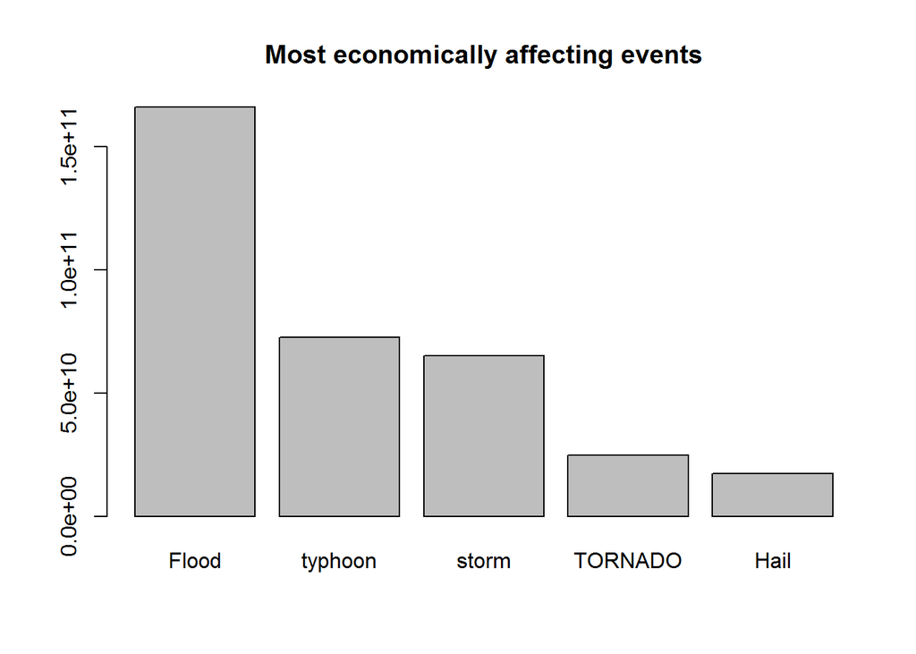

```r
selData$TotalDamage<-selData$PropertyDamage+selData$CropDamage

totalEconomic<-aggregate(selData$TotalDamage,by=list(Event=selData$EVTYPE),FUN=sum, na.rm=TRUE, simplify = TRUE)
#sort
totalEconomic<-totalEconomic[with(totalEconomic, order(-x)),]
#select top 5
totalEconomic<-totalEconomic[1:5,]
#plot it
barplot(totalEconomic$x,names.arg = totalEconomic$Event, main = "Most economically affecting events")
```

Lets calculate total health effects. Here as well we will only plot top 5 events.

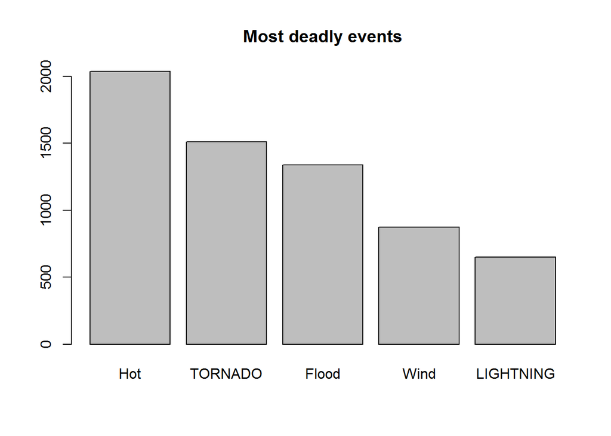

```r
selData$FATALITIES<-as.integer(selData$FATALITIES)
selData$NJURIES<-as.integer(selData$INJURIES)

totalDead<-aggregate(selData$FATALITIES,by=list(Event=selData$EVTYPE),FUN=sum, na.rm=TRUE, simplify = TRUE)
totalDead<-totalDead[with(totalDead, order(-x)),]
#select top 5
totalDead<-totalDead[1:5,]
#plot it
barplot(totalDead$x,names.arg = totalDead$Event, main = "Most deadly events")
```

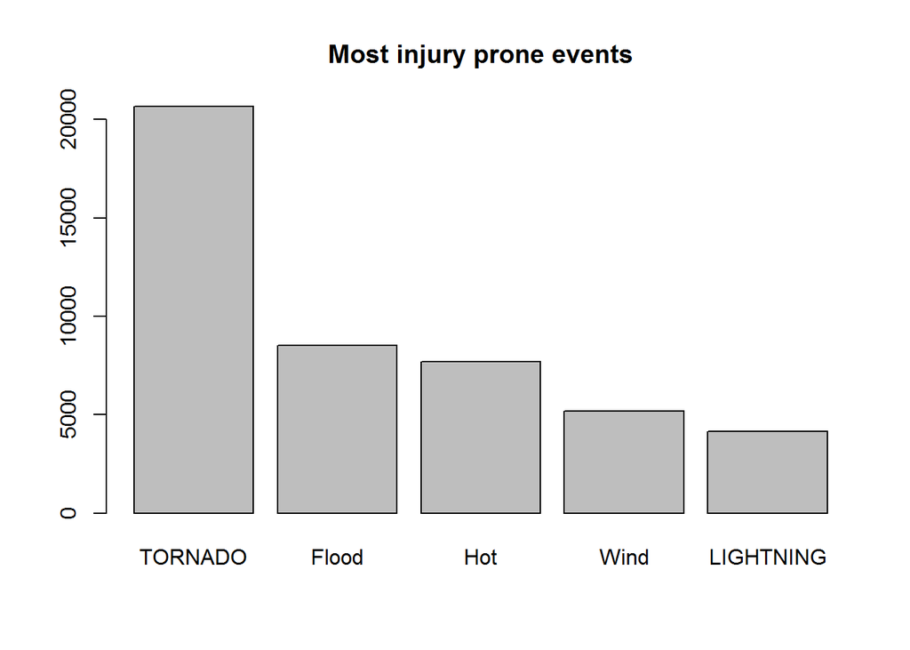

```r
#no idea why I need to convert to integer again
totalInjury<-aggregate(as.integer(selData$INJURIES),by=list(Event=selData$EVTYPE),FUN=sum, na.rm=TRUE, simplify = TRUE)
totalInjury<-totalInjury[with(totalInjury, order(-x)),]
#select top 5
totalInjury<-totalInjury[1:5,]
#plot it
barplot(totalInjury$x,names.arg = totalInjury$Event, main = "Most injury prone events")
```

# Results

Storms and other severe weather events can cause both public health and economic problems for communities and municipalities. Many severe events can result in fatalities, injuries, and property damage, and preventing such outcomes to the extent possible is a key concern.

Following assumptions have been made

- only 1996+ data was analysed
- for PROPDMGEXP and CROPDMGEXP values are
- K = 10^3
- M = 10^6
- B = 10^9
- everything else (few records after 1996) ==1.

This is a very quick summary (due to time constrains) and more in-depth research is recommended.